# A Statistical Test of the Symmetry of the Stock Returns Distributions

Dr. Hossain Pezeshki

2015-07-08

# Prompt and Summary

A recent online [article](http://www.bloombergview.com/articles/2015-06-25/fear-factor-drives-the-stock-market-s-highs-and-lows) (Smith 2015) reports the existence of negative skewness in the distribution of (some) stock returns, and we decided to test this assertion. That is, we decided to test stock returns data for symmetry. Commonly, the statistical skewness is used for this purpose. However, in order for skewness to be meaningful at all, the distribution must have finite third order moments. Furthermore the test of significance of sample skewness requires the existence of bounded moments of sixth order. Thus, the fact that the observed return distributions are often heavy-tailed (page 87 Ruppert 2011) makes skewness inappropriate for the task at hand, and a different test is needed. We propose such a test after reviewing the skewness metric.

Although our primary focus is finance, our discussion is broadly applicable to large sample statistics.

## Skewness and its requirement of bounded moments

Let $x = [x_1, x_2,\ldots, x_N]$ be a sample from a population governed by the pdf $f_X()$. Then, if $\int_{\mathbb{R}} \left|r \right|^3 f_X(r)\,dr < \infty$, define the population skewness $\gamma_3$ by $\gamma_3 \stackrel{\Delta}{=} E \left( \dfrac{X - \mu_1}{\sqrt{\mu_2}} \right)^3$ where $\mu_1 = EX$ and $\mu_2 = \mbox{Var}(X)$. The corresponding sample estimate skewness $\Gamma_{3,N}$ is given by $\Gamma_{3,N} \stackrel{\Delta}{=} \dfrac{1}{N} \sum_{i=1}^{N} \left( \dfrac{x_i - m_N}{s_N} \right)^3$ where $m_N$ and $s_N$ are the sample mean and standard deviation respectively. By the strong law of large number $\Gamma_{3,N} \rightarrow \gamma_3$ as $N \rightarrow \infty$. Clearly if $f_X()$ is symmetric then $\gamma_3 \equiv 0$, so that $\left|\Gamma_{3,N}\right|$ can be used as a test statistic since its large values betoken asymmetry. The critical values for this test come from the asymptotic noramlity of $\Gamma_{3,N}$. It is shown on pages 386–387 of Lehmann (2010) that $\sqrt{N}\,(\Gamma_{3,N} - \gamma_3) \rightarrow N(0,b)\;\; \mbox{where}\;\; b \stackrel{\Delta}{=} \dfrac{ \mu_6 - 6 \mu_2 \mu_4 - \mu_3^2 + 9 \mu_2^3 } {\mu_2^3}$ where $\mu_k \stackrel{\Delta}{=} E\left(X - EX)\right)^k\;$ for $k \in \{2,3,4,5,6\}$.

# A different test of symmetry

Let $f_X$ and $F_X$ be the population probability density function and cumulative distribution function respectively. Considering the (potential) heaviness of the tails of $f_X$, we can only reasonably assume boundedness of the first moment $\int_{\mathbb{R}} \left|r \right| f_X(r)\,dr < \infty$. That is, the expectation $EX$ is finite. We propose using as the test statistic the absolute value of the difference between the sample mean and sample median normalized by an indication of the *scale* parameter; that is, $T_N$ as defined below:

$T_N \stackrel{\Delta}{=} \dfrac{\left|m_N - \zeta_{1/2,N}\right|} {R_N} \;\;\mbox{where}\;\; R_N \stackrel{\Delta}{=} \dfrac{\zeta_{3/4,N} - \zeta_{1/4,N}} {2 \times 0.6745}$ where by $\zeta_{p,N}$ we mean the the $p$’th sample quantile. Our choice of $R_N$ is motivated by the discussion on page 86 of Serfling (1980) where in particular the strange looking denominator of $R_N$ is explained. Large values of $T_N$ suggest rejecting the null hypothesis: $H_0 : \;\;f_X\;\;\mbox{is symmetric}$

Clearly we need to approximate the distribution of $T_N$ under $H_0$; to this end we use a trick suggested by Davison and Hinkley (2007) and proceed as follows: Let $F_N$ be the empirical cumulative distribution function of the data $x = [x_1, x_2,\ldots, x_N]$. By the authority of the Gilvenko-Cantelli theorem (Billingsley 1995, 269), $F_N$ is an approximation of $F_X$. Create a *new* data set $y = [y_1, y_2,\ldots,y_N]$ by setting $y_i \stackrel{\Delta}{=} 2\,\zeta_{1/2,N} - x_i \;\;\mbox{for}\;\; i \in \{1,\ldots,N\}$ and let $G_N$ be the empirical cdf of $y$. If the null hypothesis $H_0$ is true, then $G_N$ is also an approximation of $F_X$. Consequently, under $H_0$, the cumulative distribution function $K_N$ defined by $K_N = \dfrac{1}{2} F_N + \dfrac{1}{2} G_N$ is also an approximation of $F_X$. Observe that $K_N$ is the empirical CDF of the data vector $w$ that we obtain by concatenating the vectors $x$ and $y$ as $w \stackrel{\Delta}{=} [x_1,\ldots,x_N, y_1,\ldots, y_N]$. Clearly $K_N$ is a symmetric distribution. We can therefore approximate the null distribution of our test statistic $T_N$ by forming bootstrap samples $w_1^\ast, w_2^\ast,\ldots,w_B^\ast$ from $w$ and applying $T_N$ to each bootstrap sample to obtain $T_{N,1}^\ast, T_{N,2}^\ast,\ldots, T_{N,B}^\ast$ The corresponding *basic bootstrap* $p$-value for $T_N$ is given by

$p_N^\ast \stackrel{\Delta}{=} \dfrac{1 + \sum_{i=1}^{B} \mathbb{1}\left( T_{N,i}^\ast \geq T_N \right)} {1 + B}$ The above basic bootstrap estimate can be improved upon by using antithetic variance reduction and balanced bootstrap, as the following implementation in [`R 3.2.0`](http://www.R-project.org) (R Core Team 2015) does.

```r
rm (list = ls())
require (gtools)

lu <- defmacro (j, k, expr={
  c((k*(j-1)+1):(k*j))
})

symmetry.statfunc <- function (y) {
  mu <- mean (y);
  md <- median (y);
  tmp <- quantile (x=y, probs=c(1/4, 3/4));
  s <- (tmp[2] - tmp[1])/ (2 * 0.6745);  # Indication of scale
  val <- abs (mu - md) / s;
  names (val) <- NULL
  val;
}

symmetryTest <- function (x, B = 1000) {
  stopifnot (class(x) == "numeric")
  result <- list();
  result$statistic <- symmetry.statfunc (x);
  result$mu <- mean(x);
  result$md <- median(x);
  tmp <- quantile (x=x, probs=c(1/4, 3/4));
  result$scale  <- (tmp[2] - tmp[1])/ (2 * 0.6745);  # Indication of scale
  names (result$scale) <- NULL

  Hnull = c(x, (2*median(x)-x)) # This is the symmetrized data which is our proxy for H0

  # Note the use of balanced as opposed to ordinary bootstrap,
  # together with the use of antithetic variates.
  # Page 493 of Hinkley et al. exercise 21
  halfB = as.integer (B/2);
  direct.val = rep (0.0, halfB)
  anti.val = rep (0.0, halfB)

  BI <- rep (c(1:length(Hnull)), halfB);
  II <- sample (x=BI, size=length(BI), replace=FALSE)

  for (i in 1:halfB) {
    idx = lu (i, length(Hnull))
    jdx = II[idx]
    direct.val[i] = symmetry.statfunc(Hnull[jdx])

    jdx = (length(Hnull)+1) - jdx
    anti.val[i] = symmetry.statfunc (Hnull[jdx])
  }

  val = c (direct.val, anti.val)
  result$p.val <- (1 + sum (val >= result$statistic))/(1+B);

  result
}
```

## Experimenting with known distribution

To gauge the performance of the above procedure we first try it on simulated data with known asymmetry (or symmetry). The following plot shows the pdf of the stable law with characteristic index $\alpha = 1.4$ and skew parameter $\beta=0.45$ as well as the symmetric stable law with $\alpha=1.4$ (i.e. $\beta=0$). Neither distribution has finite variance (A reference on stable laws is Samorodnitsky and Taqqu (1994)).

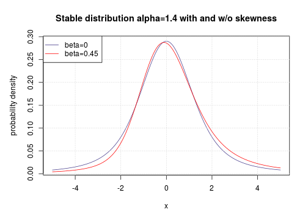

We simulate samples corresponding to the above two distribution and subject them to our test.

```r
set.seed (35384)
data = rstable (n=300, alpha=alpha, beta=0.0)
res = symmetryTest (data, B=2000)
print (res$p.val)
```

```
## [1] 0.287856071964
```

As expected, there is no evidence against symmetry for the blue density.

```r
set.seed (35384)
print (beta)
```

```
## [1] 0.45
```

```r
data = rstable (n=300, alpha=alpha, beta=beta)
res = symmetryTest (data, B=2000)
print (res$p.val)
```

```
## [1] 0.0189905047476
```

As expected, the test rejects $H_0$ for the red density in the above figure.

Next we apply the test to data simulated from $t$ distribution with $\mbox{df}=2.1$, with non-centrality parameter $\mbox{nc}=0$ and $\mbox{nc}=0.45$, which are plotted below. Both $t_{\mbox{df}=2.1}$ and $t_{\mbox{df}=2.1, \mbox{nc}=0.45}$ have unbounded third moments. Note that we have centred the non-central $t$ pdf at its mean so as to highlight the difference of skewnesses of the two pdf’s.

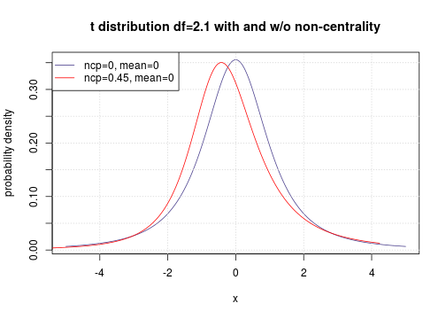

```r
set.seed (35384)
print (df)
```

```
## [1] 2.1
```

```r
data = rt (n=300, df=df)
print (symmetryTest (data)$p.val)
```

```
## [1] 0.985014985015
```

As expected there is no evidence of asymmetry for the blue curve.

```r
set.seed (35384)
print (ncp)
```

```
## [1] 0.45
```

```r
data = rt (n=300, df=df, ncp=ncp)
print (symmetryTest (data)$p.val)
```

```
## [1] 0.014985014985
```

But the test rejects the red curve.

# Trying the test out on market data

We use the quantmod (Ryan 2015) package of R 3.2.0 to download market data from [Yahoo Finance Canada](https://ca.finance.yahoo.com/).

```r
rm (list = ls())
library (quantmod)
source ("./getTicker.R") # This is a just a convenient wrapper for getSymbols{quantmod}
source ("symmetryTest.R")
set.seed (38535)
```

Let us try the [S&P 500](https://en.wikipedia.org/wiki/S&P_500) daily log-returns for the past two years.

```r
SNP500 <- getTicker (sym="^GSPC", freq="daily", from="2013-07-10", to="2015-07-10")
SNP500$symTest = symmetryTest (SNP500$rt, B=2000)
print (SNP500$symTest$p.val)
```

```
## [1] 0.508745627186
```

There is no evidence of asymmetry in S&P 500 returns. Next we try [PowerShares QQQ Trust, Series 1](https://ca.finance.yahoo.com/q?s=QQQ&ql=1) daily log-returns for the same period.

```r
getTicker (sym="QQQ", auto.assign=TRUE,
           freq="daily", from="2013-07-10", to="2015-07-10")
QQQ$symTest = symmetryTest (QQQ$rt, B=2000)
print (QQQ$symTest$p.val)
```

```
## [1] 0.0899550224888
```

```r
sprintf ("QQQ daily log returns: mean=%.4f, median=%.4f", QQQ$symTest$mu, QQQ$symTest$md)
```

```
## [1] "QQQ daily log returns: mean=0.0008, median=0.0012"
```

There is evidence of asymmetry in [QQQ](https://ca.finance.yahoo.com/q?s=QQQ&ql=1) daily log-returns, and the claim of negative skewness made in the cited [article](http://www.bloombergview.com/articles/2015-06-25/fear-factor-drives-the-stock-market-s-highs-and-lows) is verified since the mean is less than the median. However, there does not appear to be any strong indication of negative skewness of daily log-returns of IBM and Microsoft for the same period:

```r
getTicker (sym="IBM", auto.assign=TRUE,
           freq="daily", from="2013-07-10", to="2015-07-10")
IBM$symTest = symmetryTest (IBM$rt, B=2000)
print (IBM$symTest$p.val)
```

```
## [1] 0.543728135932
```

```r
getTicker (sym="MSFT", auto.assign=TRUE,
           freq="daily", from="2013-07-10", to="2015-07-10")
MSFT$symTest = symmetryTest (MSFT$rt, B=2000)
print (MSFT$symTest$p.val)
```

```
## [1] 0.100949525237
```

For the [S&P/TSX Composite Index](https://en.wikipedia.org/wiki/S&P/TSX_Composite_Index) of the [Toronto Stock Exchange](https://en.wikipedia.org/wiki/Toronto_Stock_Exchange), there appears to be a very strong evidence of negative skewness since the p-value is small and the mean is less than the median:

```r
TSE = getTicker (sym="^GSPTSE",
           freq="daily", from="2013-07-10", to="2015-07-10")
TSE$symTest = symmetryTest (TSE$rt, B=2000)
print (TSE$symTest$p.val)
```

```
## [1] 0.000499750124938
```

```r
sprintf ("TSX daily log returns: mean=%.4f, median=%.4f", TSE$symTest$mu, TSE$symTest$md)
```

```
## [1] "TSX daily log returns: mean=0.0003, median=0.0008"
```

# Conclusion

Presence of asymmetry and negative skewness in the distribution of the log-returns of stocks and stocks indices is not necessarily universally true, and should be tested on a case-by-case basis.

References

Billingsley, Patrick. 1995. *Probability and Measure*. third. John Wiley & Sons.

Davison, A.C., and D.V. Hinkley. 2007. *Bootstrap Methods and Their Application*. Cambridge University Press.

Lehmann, E.L. 2010. *Elements of Large Sample Theory*. Springer Texts in Statistics. Springer-Verlag.

R Core Team. 2015. *R: A Language and Environment for Statistical Computing*. Vienna, Austria: R Foundation for Statistical Computing. http://www.R-project.org/.

Ruppert, David. 2011. *Statistics and Data Analysis for Financial Engineering*. Springer.

Ryan, Jeffrey A. 2015. *Quantmod: Quantitative Financial Modelling Framework*. http://CRAN.R-project.org/package=quantmod.

Samorodnitsky, G., and M.S. Taqqu. 1994. *Stable Non-Gaussian Random Processes: Stochastic Models with Infinite Variance*. Chapman & Hull.

Serfling, Robert J. 1980. *Approximation Theorems of Mathematical Statistics*. John Wiley & Sons Inc.

Smith, Noah. 2015. “The Fear Factor Behind Stock Prices.” http://www.bloombergview.com/articles/2015-06-25/fear-factor-drives-the-stock-market-s-highs-and-lows.